# flight control maps - Google Search

radar

airspace

malaysia airlines flight mh370

flight tracker

flight 370

icao

flightradar24

flight tracking

flight status

ads b

kuala lumpur

tower

federal aviation

aviation administration

gis

route traffic

control centers

## Search Results

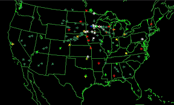

796 × 483

Flight traffic mapping - Wikipedia

en.wikipedia.org

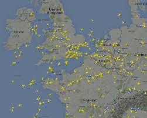

1000 × 800

flightradar24.com

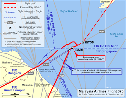

1280 × 999

File:MH370 ATC-Routes map.png ...

commons.wikimedia.org

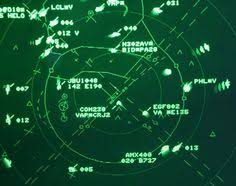

236 × 186

Flight control centre maps and imagery ...

pinterest.ie

[figure not shown]

1300 × 955

Air Traffic Control Stock Photos & Air ...

alamy.com

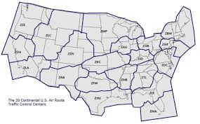

424 × 264

Flight Traffic over North America

maps.unomaha.edu

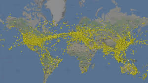

1100 × 618

Busiest Days ...

mentalfloss.com

[figure not shown]

1300 × 955

Computer monitors in the air traffic ...

alamy.com

[figure not shown]

1200 × 1200

Flightradar24: Live Flight Tracker ...

flightradar24.com

[figure not shown]

1030 × 579

Live ATC audio & flight tracking

nonstopsystems.com

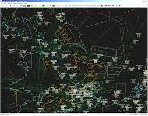

1280 × 998

PlanePlotter from COAA

coaa.co.uk

[figure not shown]

1201 × 407

ICAO Public Maps

gis.icao.int

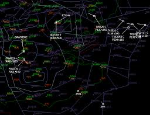

650 × 501

Pin on radar reference

pinterest.com

[figure not shown]

1300 × 928

Air Traffic Control Map Stock Photos ...

alamy.com

[figure not shown]

1280 × 720

September 11th 2001 Airspace Shutdown ...

youtube.com

September 11th 2001 Airspace Shutdown (With Timeline)

Watch (1:55)

Uploaded by: AIRBOYD,Aug 30, 2011

2.18MViews · 16.75KLikes · 0Comments

Click to subscribe! http://bit.ly/subAIRBOYD Courtesy: NASA/FAA NASA Ames Research Center Future Air Traffic Management Concepts and Evaluation Tool (FACET) ...

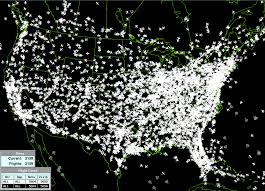

1024 × 738

new era begins with geospatially based ...

gpsworld.com

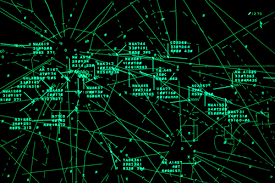

500 × 334

FAA.travel ZMA

faa.travel

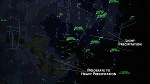

1920 × 1080

What the ATC controller sees – tech in ...

atctower.com

[figure not shown]

1032 × 742

Aeronautical Charts in Flightradar24 ...

flightradar24.com

[figure not shown]

1300 × 956

Air Traffic Control Map Stock Photos ...

alamy.com

[figure not shown]

700 × 467

Air Traffic Controllers

thepointsguy.com

[figure not shown]

670 × 1451

Airline Flight Path Tracking Sites and Apps

makeuseof.com

[figure not shown]

680 × 480

Area control center - Wikipedia

en.wikipedia.org

[figure not shown]

1920 × 1080

Flight Radar Screen

e993.com

Related searches

live flight radar 24

air traffic control centers map

air traffic control world map

[figure not shown]

917 × 613

air traffic control at Orlando ...

news965.com

[figure not shown]

398 × 540

How Air Traffic Control Works ...

science.howstuffworks.com

[figure not shown]

410 × 294

Missing Malaysia plane MH370: What we ...

bbc.com

[figure not shown]

1810 × 830

Tracking a flight

support.jeppesen.com

[figure not shown]

1200 × 641

Aircraft Noise and Flight Tracking ...

flysfo.com

[figure not shown]

975 × 768

Linux in Air Traffic Control | Linux ...

linuxjournal.com

[figure not shown]

893 × 1030

What the risks of flying through Africa ...

flightdeckfriend.com

[figure not shown]

391 × 220

Flight Tracker Radar: Live Air Traffic ...

play.google.com

[figure not shown]

450 × 800

mi Flight Radar & Tracker Pro - Online ...

gehack.com

[figure not shown]

852 × 480

Air Traffic Control Radar. Animation ...

shutterstock.com

Air Traffic Control Radar. Animation. Stock Footage Video (100% Royalty-free) 1022343703 | Shutterstock

$52.00*

Get a 10.000 second air traffic control radar. animation. stock footage at 30fps. 4K and HD video ready for any NLE immediately. Choose from a wide ...

* Check website for latest pricing and availability. Images may be subject to copyright. [Learn more](https://support.google.com/legal/answer/3463239)Image credits

[figure not shown]

410 × 367

EgyptAir flight MS804: What we know ...

bbc.com

[figure not shown]

493 × 290

Self-assessment maps - NATS

nats.aero

[figure not shown]

750 × 1334

7 Best Apps for Aviation Geeks

thepointsguy.com

[figure not shown]

850 × 539

1 Air Traffic Control Centers in the ...

researchgate.net

[figure not shown]

400 × 226

ICAO Public Maps

gis.icao.int

[figure not shown]

900 × 815

Missing plane map: Search area widens ...

abc.net.au

[figure not shown]

450 × 450

Air traffic control Stock Vectors ...

depositphotos.com

[figure not shown]

450 × 225

North Atlantic Tracks - Wikipedia

en.wikipedia.org

[figure not shown]

530 × 315

Air Traffic Control, Fighter Jets ...

portlandmercury.com

[figure not shown]

481 × 258

History of Air Traffic Control | USCA

usca.es

[figure not shown]

1170 × 571

Flightradar24 - Track your plane in the ...

trackmyflight24.com

[figure not shown]

496 × 648

New Zealand Scheduled Flight Paths Map ...

ufocusnz.org.nz

Related searches

live air traffic map

flightradar24 flight radar

flight radar 24 app

[figure not shown]

1000 × 524

Live ATC audio & flight tracking

nonstopsystems.com

[figure not shown]

630 × 337

Top 5 Air Traffic Control Games | Best ...

incomopedia.com

[figure not shown]

1424 × 890

ARTMACS Radar

canadiandatasoft.com

[figure not shown]

1920 × 1080

What the ATC controller sees – tech in ...

atctower.com

[figure not shown]

602 × 332

How many airplanes are in flight on ...

quora.com

[figure not shown]

325 × 280

flight control screen Images, Stock ...

shutterstock.com

[figure not shown]

1280 × 720

Track your flight on the flight radar ...

flightradar.online

[figure not shown]

1140 × 415

displayed on civilian ATC radar screens ...

aviation.stackexchange.com

[figure not shown]

800 × 800

Flightradar24: Live Flight Tracker ...

flightradar24.com

[figure not shown]

500 × 381

Air traffic control towers | Airservices

airservicesaustralia.com

[figure not shown]

1563 × 1042

ADS-B – Coverage Map

faa.gov

[figure not shown]

1280 × 720

Transatlantic flight paths of 2,524 ...

theguardian.com

Transatlantic flight paths of 2,524 planes on single day - video animation

Watch (1:59)

Jul 3, 2014

An animation by Nats, the UK air traffic control service, demonstrates the flight paths of 2,524 aircraft across the North Atlantic on a single day

[figure not shown]

927 × 686

Radio Navigation – Radar Beacon Transponder

flight-mechanic.com

[figure not shown]

675 × 363

ICAO Public Maps

gis.icao.int

[figure not shown]

478 × 301

FAA Issues New Rules For Air Traffic ...

winncad.blogspot.com

[figure not shown]

1930 × 1299

Busiest Days ...

mentalfloss.com

[figure not shown]

850 × 995

Data coverage map for OIB flight tracks ...

researchgate.net

[figure not shown]

760 × 388

planes are as they fly over ...

popsci.com

[figure not shown]

420 × 240

A Map of Every Passenger Plane in the ...

smithsonianmag.com

[figure not shown]

600 × 600

General Aviation Solutions | Garmin

garmin.com

[figure not shown]

750 × 1050

Air traffic control - Wikipedia

en.wikipedia.org

[figure not shown]

1125 × 2436

Airline Flight Path Tracking Sites and Apps

makeuseof.com

Related searches

air traffic control map canada

air traffic control map europe

airspace map

[figure not shown]

700 × 554

KLM Flights free live Flighttracking ...

flight-tracker.org

[figure not shown]

2880 × 1800

Flight Simulator in Google Earth

lifewire.com

[figure not shown]

800 × 600

Air Traffic Control School ...

airspacemag.com

[figure not shown]

1024 × 576

Radar Live: FLYRADAR 24 | Flight ...

radar-live.com

[figure not shown]

4000 × 2667

4 Best Flight Tracker Apps for 2019 ...

cntraveler.com

[figure not shown]

858 × 536

air traffic control ...

telegraph.co.uk

[figure not shown]

845 × 321

What the risks of flying through Africa ...

flightdeckfriend.com

[figure not shown]

571 × 1017

The World's best flight tracker app ...

flightradar24.com

[figure not shown]

2226 × 1476

X-Plane 11 Desktop Manual | X-Plane

x-plane.com

[figure not shown]

1280 × 720

X Plane plugins and addons: External ...

youtube.com

X Plane plugins and addons: External moving Map (google Maps)

Watch (8:16)

Uploaded by: Laminar Flow Gaming,Jan 29, 2017

57.85KViews · 326Likes · 0Comments

Today's video looks a little X-plane plugin that helps to track your flight on a Web browser session on your PC, or another laptop or tablet on your local ne...

[figure not shown]

800 × 993

plane fly in a zigzag pattern ...

aviation.stackexchange.com

[figure not shown]

450 × 449

ᐈ Atc radar screen stock vectors ...

depositphotos.com

[figure not shown]

340 × 227

Adelaide pilot leaves 'I'm bored ...

abc.net.au

[figure not shown]

829 × 1024

Introduction to Airspace - NATS

nats.aero

[figure not shown]

995 × 628

Flight Tracking ...

bellingcat.com

[figure not shown]

1730 × 1254

Airlines fly bizarre flight paths to ...

independent.co.uk

[figure not shown]

1920 × 1080

What the ATC controller sees – tech in ...

atctower.com

[figure not shown]

596 × 410

How Flight Tracking Apps Work: Volunteers

fastcompany.com

[figure not shown]

450 × 800

mi Flight Radar & Tracker Pro - Online ...

gehack.com

[figure not shown]

990 × 1197

Missing Malaysia Airlines Plane

nationalgeographic.com

[figure not shown]

1600 × 620

General Aviation Solutions | Garmin

garmin.com

[figure not shown]

700 × 555

FAA Briefly Delays Flights at LaGuardia ...

wsj.com

Related searches

air traffic control screen

global air traffic control map

air traffic control map asia

[figure not shown]

1125 × 2436

Airline Flight Path Tracking Sites and Apps

makeuseof.com

[figure not shown]

1200 × 750

Why aircraft don't always fly in ...

eurocontrol.int

[figure not shown]

753 × 800

AirNav RadarBox - Live Flight Tracker ...

radarbox24.com

[figure not shown]

1200 × 1550

ForeFlight - Military Flight Bag

foreflight.com

[figure not shown]

750 × 500

MH370 pilot was in control of doomed ...

thesun.co.uk

[figure not shown]

1600 × 1000

Military Aircraft Tracker | Plane ...

planeflighttracker.com

[figure not shown]

800 × 513

WebTrak | Airservices

airservicesaustralia.com

[figure not shown]

360 × 240

Approach and Landing | HowStuffWorks

science.howstuffworks.com

[figure not shown]

602 × 370

buttons and knobs do on a weather radar ...

quora.com

[figure not shown]

Facebook

[figure not shown]

Twitter

[figure not shown]

Email

Click to copy link

Share link

OK

[figure not shown]

720 × 480

giphy.com

[Air Traffic GIF - Find & Share on GIPHY](https://giphy.com/gifs/air-traffic-global-cPutGcE0a9jdS)

Discover & share this Air GIF with everyone you know. GIPHY is how you search, share, discover, and create GIFs.

Images may be subject to copyright. [Learn more](https://support.google.com/legal/answer/3463239)

Related imagesSee more

[figure not shown]

1100 × 618

Aircraft Tracker Visualizes One of the Busiest Days Ever in Air Travel | Mental Floss

mentalfloss.com

[figure not shown]

1024 × 540

Rune Mo on Twitter: "Awesome #FlightRadar24 #GIF https://t.co/5avSMUSjOf… "

twitter.com

[figure not shown]

1100 × 744

Wednesday was the busiest recorded air-travel day in history - Business Insider

businessinsider.com

[figure not shown]

1024 × 617

The Evolution of Flightradar24 Coverage | Flightradar24 Blog

flightradar24.com

[figure not shown]

200 × 133

Air traffic control GIFs - Get the best gif on GIFER

gifer.com

[figure not shown]

634 × 471

Footage shows over 200,000 flights took off and landed on Friday | Daily Mail Online

dailymail.co.uk

[figure not shown]

600 × 400

Watch 24 Hours of Flights In A Minute (Awesome Video) - South Florida Reporter

southfloridareporter.com

[figure not shown]

651 × 368

Real-Time Air and Marine Traffic | Postscapes

postscapes.com

[figure not shown]

1000 × 800

North America GIF - Find & Share on GIPHY

giphy.com

[figure not shown]

504 × 504

Malaysia Airlines Ukraine Crash: How Ukraine's Airspace Emptied Out | Time

time.com

[figure not shown]

1915 × 1029

AvTalk Episode 14: Jason, Go Make Your Bed | Flightradar24 Blog

flightradar24.com

[figure not shown]

1170 × 429

April 2016 – Flightradar24 Blog

flightradar24.com

See more

Sri Lanka